# Bellabeat Case Study

Alan Roebuck

2023-09-30

This case study was performed as a part of the Google Analytics career certificate course. All code necessary to reproduce visual and statistical analysis associated with this project are available via [Github](https://github.com/jar3559/Bellabeat_Case_Study_Google_Analytics).

## **1. Case Study Scenario**

You are a junior data analyst working on the marketing analyst team at Bellabeat, a high-tech manufacturer of health-focused products for women. Bellabeat is a successful small company, but they have the potential to become a larger player in the global smart device market. Urška Sršen, cofounder and Chief Creative Officer of Bellabeat, believes that analyzing smart device fitness data could help unlock new growth opportunities for the company. You have been asked to focus on one of Bellabeat’s products and analyze smart device data to gain insight into how consumers are using their smart devices. The insights you discover will then help guide marketing strategy for the company. You will present your analysis to the Bellabeat executive team along with your high-level recommendations for Bellabeat’s marketing strategy.

- **Bellabeat Products**
  - *Bellabeat app:* The Bellabeat app provides users with health data related to their activity, sleep, stress, menstrual cycle, and mindfulness habits. This data can help users better understand their current habits and make healthy decisions. The Bellabeat app connects to their line of smart wellness products
  - *Leaf:* Bellabeat’s classic wellness tracker can be worn as a bracelet, necklace, or clip. The Leaf tracker connects to the Bellabeat app to track activity, sleep, and stress.
  - *Time:* This wellness watch combines the timeless look of a classic timepiece with smart technology to track user activity, sleep, and stress. The Time watch connects to the Bellabeat app to provide you with insights into your daily wellness
  - *Spring:* This is a water bottle that tracks daily water intake using smart technology to ensure that you are appropriately hydrated throughout the day. The Spring bottle connects to the Bellabeat app to track your hydration levels.

## **2. Assignment**

You are asked to analyze smart device usage data in order to gain insight into how consumers use non-Bellabeat smart devices and to select one Bellabeat product to apply these insights to in your presentation. These question will guide your analysis:

1. What are some trends in smart device usage?
2. How could these trends apply to Bellabeat customers?
3. How could these trends help influence Bellabeat marketing strategy?

## **3. Data Availability and Description**

### *3.1 Data Source*

To complete this project, data for Fitbit users at various time resolutions was obtained from [Kaggle](https://www.kaggle.com/datasets/arashnic/fitbit), which was originally sourced from Furberg et al., 2016, doi: 10.5281/zenodo.53894.

### *3.2 Data Files*

The dataset consist of the following files:

| File Name | Description |
| --- | --- |
| dailyActivity_merged.csv | Daily calories, steps, and intensities (active minutes) |
| dailyCalories_merged.csv | Total daily calories burned |
| dailyIntensities_merged.csv | Total daily minutes for which users were active or sedentary |
| dailySteps_merged.csv | Total daily steps |
| heartrate_seconds_merged.csv | User heart rate beats per minute at second intervals |
| hourlyCalories_merged.csv | Hourly calories |
| hourlyIntensities_merged.csv | Number of active and sedentary minutes by hour |
| hourlySteps_merged.csv | Number of hourly steps |
| minuteCaloriesNarrow_merged.csv | Calories burned by minute in long frame format |
| minuteCaloriesWide_merged.csv | Calories burned by minute in wide frame format |
| minuteIntensitiesNarrow_merged.csv | Active and sedentary minutes in long format |
| minuteIntensitiesWide_merged.csv | Active and sedentary minutes in wide format |
| MInuteMETsNarrow_merged.csv | Metabolic equivalents (MET) per minute |
| minuteSleep_merged.csv | Each individual minute logged as sleep |
| minuteStepsNarrow_merged.csv | Steps logged each minute long format |
| minuteStepsWide_merged.csv | Steps logged each minute wide format |
| sleepDay_merged.csv | Total number of minutes slept per day |
| weightLogInfo_merged.csv | Information related to user weight |

### *3.3 Initial Assessment of Data*

Broadly, it cannot be said with confidence this data is a good representation of the Bellabeat client base, which targets middle age women. For instance, this dataset provides no information on race, sex, age, nor geographic information. Thus, we can only make small inferences regarding the broader fitness community rather than specifically those specifically related to women.

Furthermore, this data is quite limited, with only 33 participants over a 31 day period. Thus, we would most likely consider this data a preliminary effort to better inform the design of a larger study rather than being directly used to inform major decisions.

## **4. Questions and Hypotheses**

Here, a set of 5 questions and corresponding hypothesis are presented. Questions 1-3 ask about general fitness patterns for users who participated in the study while questions 4 and 5 are directly linked with how users use the fitness watches and products with implications marketing strategy.

**Q1:** When are people most active throughout the day and does that couple with energy expenditure? How does this compare among people of different activity level?

- *H1:* It is hypothesized that all users of all activity levels will be most active in the late evening, likely due to uptick in workouts at the end of the day or due to general after work/ after school activities that will occur

**Q2:** Are people more active during the typical workweek or on weekends and are there differences based on peoples activity level?

- *H2:* It is hypothesized that users of all activity levels will see a general increase in activity during the weekends as this is when most people have free time.

**Q3:** Do more physically active users get more hours of sleep at night?

- *H3:* It is hypothesized that sedentary users sleep more compared to active users

**Q4:** Is fitness level an indicator how many days users consistently wear a fitness watch (e.g., motivation to regularly use product)?

- *H4:* It is hypothesized that more active people are more motivated to consistently wear their fitness watch on a daily basis.

**Q5:** Is fitness level an indicator of how often wear a fitness watch to monitor sleep activity (e.g. motivation to use a product feature)?

- *H5* It is hypothesized that more active users are also more motivated to use their watch to monitor sleep activity and will more consistently wear their devices to bed.

## **5. Data Preparation, Cleaning, and Aggregation**

### *5.1 Retrieve Daily Activity, Sleep, and Weight Data*

1. First, daily activity, sleep and weight data were retrieved from the files *‘dailyActivity_merged.csv’*, *‘sleepDay_merged.csv’*, and *‘weightLogInfo_merged.csv’*.
2. The total active and sedentary minutes were totaled as a potential indicator of how much time during the day a fitness watch was worn. This is assessed in more detail in the following section
3. A BMI class ([World Health Organization](https://www.who.int/europe/news-room/fact-sheets/item/a-healthy-lifestyle---who-recommendations)) was assigned as follows:

| BMI Score | BMI Class |
| --- | --- |
| Under 18.5 | Underweight |
| 18.5 - 25 | Normal |
| 25 - 30 | Overweight |
| Over 30 | Obese |

### *5.2 Assessment of Total Active and Sedentary Minutes as Indicators of Time a Watch is Worn*

Above, the total daily active and sedentary minutes were summed to represent the cumulative time a fitness watch was worn throughout the day. However, after skimming the data, it was observed that there are a number of instances in which zero steps were logged. This is likely due to the fact that a Fitbit will continue to record data even when a watch is not worn. For instance, when a watch is not worn, Fitbit will continue to log minutes as “sedentary”.

**This indicates that the Total Wear Time calculated based on the cumulative active and sedentary minutes is not reliable** and an alternative means to assess how consistently users wear their fitness watch is needed.

```
## # A tibble: 15 × 2
##            Id active_nonuse
##         <dbl>         <int>
##  1 1503960366             1
##  2 1844505072            10
##  3 1927972279            14
##  4 4020332650            14
##  5 4057192912             1
##  6 4702921684             1
##  7 5577150313             2
##  8 6117666160             5
##  9 6290855005             5
## 10 6775888955             9
## 11 7007744171             2
## 12 7086361926             1
## 13 8253242879             1
## 14 8583815059             1
## 15 8792009665            10
```

```
## # A tibble: 1 × 1
##   total_active_nonuse
##                 <int>
## 1                  77
```

### *5.3 Aggregate Data By Individual User to Determine Average Daily Activities*

The data was aggregated by individual user to describe their **average daily activity**. The total number of days in which a watch was used was determined based on the number of daily steps taken rather than the total active and sedentary minutes, which was deemed unreliable above. However, an additional challenge with regards to assigning activity based on the number of daily steps is that there are some instances in which the step count is unreasonably low (e.g., less than 100) assuming a healthy sampling population. According to the Mayo Clinic, the average American walks 3,000-4,000 steps per day. Thus, a very loose approach is taken to say a person must have walked at least 500 steps in order for the watch to be credited as a daily use.

Once filtering to include only records above the 500 step threshold, the number of daily entries for each user were summed and the active daily use was arbitrarily defined as:

| Number of Days Counted | Daily Use Metric |
| --- | --- |
| 30+ days | High Daily Use |
| 20-29 days | Moderate Daily Use |
| Fewer than 20 days | Low Daily Use |

Second, the average daily steps for each user was determined (where daily steps > 500) and an activity score was assigned based on recommendations from the [10,000 Steps Organization](https://www.10000steps.org.au/articles/healthy-lifestyles/counting-steps/). Activity levels were assigned as follows:

| Number of Daily Steps | Activity Level |
| --- | --- |
| Fewer than 5000 | Sedentary |
| 5,000 - 10,000 | Lightly Active |
| Over 10,000 | Active |

Third, the average number of hours of sleep, total time in bed, and total time awake in bed (time in bed - hours of sleep) were calculated.

Fourth, a table containing the individual user and their BMI was made.

Finally, all aggregated data just described were merged

```
## # A tibble: 6 × 14
##           Id days_used active_use    avg_steps sd_steps activity_level BMI_class
##        <dbl>     <int> <chr>             <dbl>    <dbl> <chr>          <chr>
## 1 1503960366        30 High Daily U…    12521.    2099. Active         Normal
## 2 1624580081        31 High Daily U…     5744.    6177. Lightly Active Not Repo…
## 3 1644430081        30 High Daily U…     7283.    4325. Lightly Active Not Repo…
## 4 1844505072        17 Low Daily Use     4690.    1823. Sedentary      Not Repo…
## 5 1927972279        13 Low Daily Use     2115.     966. Sedentary      Obese
## 6 2022484408        31 High Daily U…    11371.    2807. Active         Not Repo…
## # ℹ 7 more variables: sleep_days_used <dbl>, avg_sleep_hr <dbl>,
## #   sd_sleep_hr <dbl>, avg_time_bed_hr <dbl>, sd_time_bed_hr <dbl>,
## #   avg_awake_hr <dbl>, sd_awake_hr <dbl>
```

### *5.4 Retrieve Hourly Calorie and Steps Data*

Hourly calorie and hourly steps data were retrieved from the files *‘hourlyCalories_merged.csv’* and *‘hourlySteps_merged.csv’*. In both cases, data is reshaped from ‘long’ to ‘wide’ format with column names renamed based on hourly intervals.

### *5.5 Clean Hourly Data*

The hourly data was cleaned by removing data where the total number of daily steps was less than 500.

```
## [1] "Hourly Steps"
```

```
##           Id       Date     active_use activity_level hr01 hr02 hr03 hr04 hr05
## 1 1503960366 2016-04-12 High Daily Use         Active  373  160  151    0    0
## 2 1503960366 2016-04-13 High Daily Use         Active  144    0    0   36    0
## 3 1503960366 2016-04-14 High Daily Use         Active   81   58    0    0    0
## 4 1503960366 2016-04-15 High Daily Use         Active   83   75  124    0    0
## 5 1503960366 2016-04-16 High Daily Use         Active  459    0   63    6    6
## 6 1503960366 2016-04-17 High Daily Use         Active    0    0    0    8    0
##   hr06 hr07 hr08 hr09 hr10 hr11 hr12 hr13 hr14 hr15 hr16 hr17 hr18 hr19 hr20
## 1    0    0    0  250 1864  676  360  253  221 1166 2063  344  489 1386  558
## 2    0    0  126  275 1679  295  524  486  302 1577  493  299  695 1343  258
## 3    0    0    0    0  902 1106   50  501 1779 1228  139  408   37  322   11
## 4   26    0    7   55   21  154  425  270  373    0    0    0 1774  509  519
## 5   12    0  101  175 1181 1295 2043 1513 3616  580    0   15  380   96  146
## 6    0    0    0    0    0    0   84  260  402  252  191   13 2613 1616  754
##   hr21 hr22 hr23 hr24
## 1 1733  684   89  338
## 2    0    0  437 1766
## 3  806 2670  362    0
## 4   77  280 2145 2768
## 5  385  463   42   92
## 6 2955  487   70    0
```

```
## [1] "Hourly Calories"
```

```
##           Id       Date     active_use activity_level hr01 hr02 hr03 hr04 hr05
## 1 1503960366 2016-04-12 High Daily Use         Active   81   61   59   47   48
## 2 1503960366 2016-04-13 High Daily Use         Active   69   48   47   53   47
## 3 1503960366 2016-04-14 High Daily Use         Active   56   54   47   47   47
## 4 1503960366 2016-04-15 High Daily Use         Active   60   58   59   47   47
## 5 1503960366 2016-04-16 High Daily Use         Active   77   48   52   48   49
## 6 1503960366 2016-04-17 High Daily Use         Active   47   48   47   49   48
##   hr06 hr07 hr08 hr09 hr10 hr11 hr12 hr13 hr14 hr15 hr16 hr17 hr18 hr19 hr20
## 1   48   48   47   68  141   99   76   73   66  110  151   76   83  124  104
## 2   47   48   59   69  136   77   84   82   72  128   79   71   87  118   73
## 3   47   47   47   47   93  109   64   85  137  113   66   88   61   72   55
## 4   49   47   49   54   50   63   84   74   67   47   47   47  140   87   97
## 5   49   48   54   62  124  110  147  119  214   82   51   54   79   65   67
## 6   48   48   48   48   48   47   63   76   83   69   73   57  174  136   95
##   hr21 hr22 hr23 hr24
## 1  132  100   65   81
## 2   47   48   74  135
## 3   91  174   79   50
## 4   64   75  151  182
## 5   81   75   55   56
## 6  191   79   58   50
```

### *5.6 Preliminary Assessment of Data Population Represented in Study*

- Here, a series of pie charts are used to display general information about fitness watch users in this study. The proportion of ‘Lightly Active’ users represents more than 50% of the data set and is overrepresented compared to ‘Active’ and ‘Sedentary’ users.
- Similarly, the number of users who more consistently wear their fitness watch is >50% and is also over represented compared to those who only moderately wore or were inconsistent in their daily fitness watch usage.
- Finally, of the 33 participants in the study, most did not provide weight information rendering use of the BMI or weight related metrics as unreliable for effective use in this study.

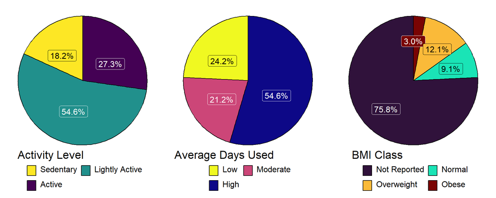

## **6. Results**

#### *Question 1: When are people most active throughout the day and does that couple with energy expendure? How does this compare among people of different activity level?*

**Major Finding:** The hypothesis that people will be most active in the evening is partially confirmed and is based primarily on a users activity level.

Key Points:

- Active Users were most active with the greatest energy expenditure during the 6-8 pm hours, likely driven by desire for physical activity after the conclusion of the work day.
- Active users also see a spike in activity around the 12-2 pm hours, likely driven by mid-day lunchtime walks.
- Lightly active users also saw a small uptick around the 12-2 pm hours suggesting some small efforts for mid-day lunchtime walks
- Sedentary users averaged <500 steps per hour with a small up tick around 7 pm that may be driven by dinnertime efforts.
  - These users also displayed slightly higher number of steps in early hours indicating these users may have a later bed time schedule.

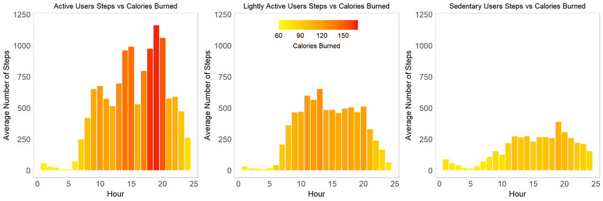

#### *Question 2: Are people more active during the typical workweek or on weekends and are there differences based on peoples activity level?*

**Major Finding:** People are equally active across the entire week rejecting the hypothesis that people would be more active on the weekends. This is true regardless of activity level.

Key Points:

- There was no significant difference in the number of steps taken for each day of the week regardless of activity level.
  - This is observed visually in the figure below noting the relatively stable average number of steps taken each day of the week for each activity level and the strong overlapping error bars
  - This observation was confirmed statistically with a non-parametric Kruskal-Wallis test for each activity level which highlight the number of steps taken each day of the week is not significantly different (p > 0.05)

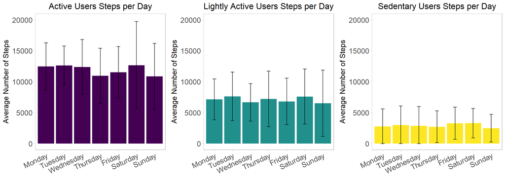

```
## [1] "Kruskal Wallis Test for Highly Active Users to determine if there are signifcant differences in the number of steps taken throught each day of the week"
```

```
## # A tibble: 1 × 6
##   .y.            n statistic    df     p method
## * <chr>      <int>     <dbl> <int> <dbl> <chr>
## 1 TotalSteps   260      10.0     6 0.123 Kruskal-Wallis
```

```
## [1] "Kruskal Wallis Test for Lightly Active Users to determine if there are signifcant differences in the number of steps taken throught each day of the week"
```

```
## # A tibble: 1 × 6
##   .y.            n statistic    df     p method
## * <chr>      <int>     <dbl> <int> <dbl> <chr>
## 1 TotalSteps   501      7.77     6 0.255 Kruskal-Wallis
```

```
## [1] "Kruskal Wallis Test for Sedentary Users to determine if there are signifcant differences in the number of steps taken throught each day of the week"
```

```
## # A tibble: 1 × 6
##   .y.            n statistic    df     p method
## * <chr>      <int>     <dbl> <int> <dbl> <chr>
## 1 TotalSteps   179      2.47     6 0.871 Kruskal-Wallis
```

#### *Question 3: Do more physically active users get more hours of sleep at night?*

**Major Finding:** There was no difference in how many hours of sleep a user received based on their activity level rejecting the hypothesis that sedentary users would likely sleep more that more active users.

Key Points:

- The average hours of sleep is provided in the table below and displayed visually in the figure below. While lightly active users had a slightly higher number of hours of sleep, this was not signficantly different (Kruskal-Wallis, p>0.05).
  - Note this analysis removed 2 outliers that indicated < 3 hours of sleep and 1 outlier that indicated > 10 hours of sleep in one night.

```
## # A tibble: 3 × 4
##   activity_level median_sleep avg_sleep sd_sleep
##   <chr>                 <dbl>     <dbl>    <dbl>
## 1 Active                 6.36      6.26    1.18
## 2 Lightly Active         7.43      7.19    1.07
## 3 Sedentary              6.68      6.61    0.629
```

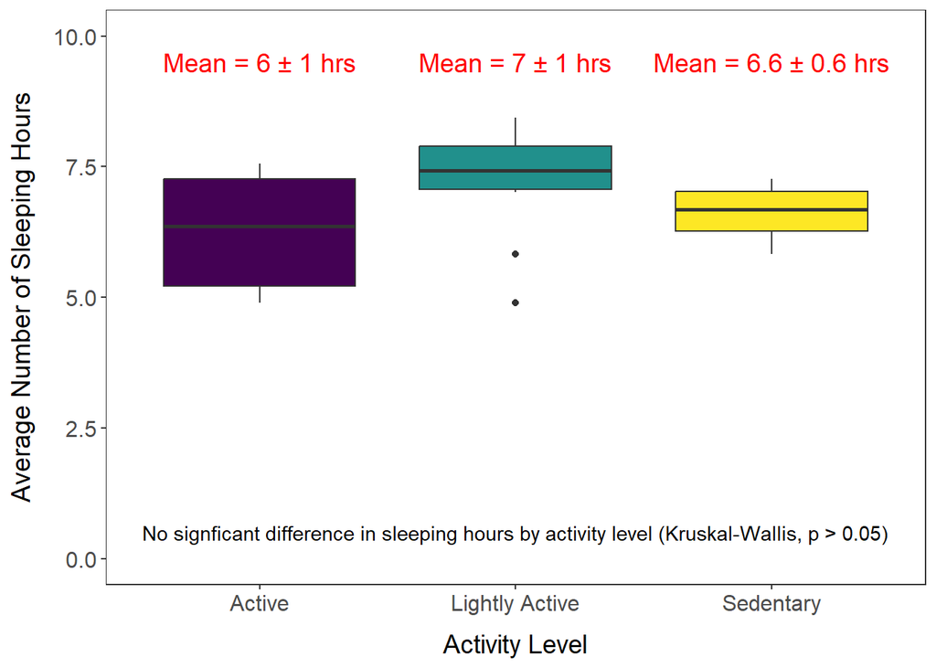

```
## [1] "Kruskal Wallis Test to determine if there is a difference in the average numbe of sleeping hours by activity level"
```

```
## # A tibble: 1 × 6
##   .y.              n statistic    df     p method
## * <chr>        <int>     <dbl> <int> <dbl> <chr>
## 1 avg_sleep_hr    20      3.30     2 0.192 Kruskal-Wallis
```

#### *Question 4: Is fitness level an indicator how many days users wear a fitness watch within a month (e.g., motivation to regularly use product)?*

**Major Findings:** Users who take more steps wear their watch more consistently indicating that more active users are likely to show higher motivation and need for purchasing a fitness watch.

Key Points:

- There was a statistically significant linkage between the number number of days a user wore their watch during the study period and the average number of steps the user took during the study period. (Spearman rank correlation, p < 0.01).
- Broadly, the number of days the fitness watch was worn during the study period was higher for active and lightly active users, although we could not statically confirm this when breaking down specifically by group (Kruskal-Wallis, p > 0.05).

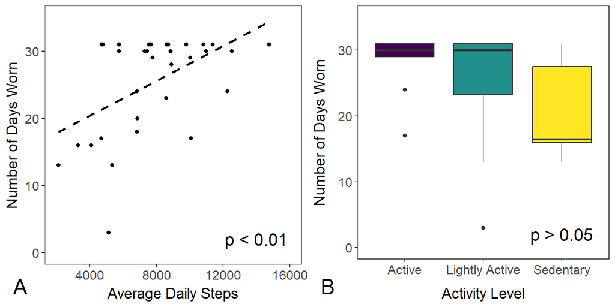

```
## [1] "Spearman Rank Correlation for the number of days the watch was used vs the average number of daily steps during the study period"
```

```
##
## Call:
## lm(formula = rank(days_used) ~ rank(avg_steps), data = data)
##
## Residuals:
##     Min      1Q  Median      3Q     Max
## -14.409  -6.420  -2.894   6.157  15.712
##
## Coefficients:
##                 Estimate Std. Error t value Pr(>|t|)
## (Intercept)       9.6165     3.0446   3.159  0.00352 **
## rank(avg_steps)   0.4343     0.1563   2.780  0.00917 **
## ---
## Signif. codes:  0 '***' 0.001 '**' 0.01 '*' 0.05 '.' 0.1 ' ' 1
##
## Residual standard error: 8.547 on 31 degrees of freedom
## Multiple R-squared:  0.1995, Adjusted R-squared:  0.1737
## F-statistic: 7.726 on 1 and 31 DF,  p-value: 0.009167
```

```
## [1] "Kruskal-Wallis test to determine if number of days worn during the study period is users of different activity level"
```

```
## # A tibble: 1 × 6
##   .y.           n statistic    df     p method
## * <chr>     <int>     <dbl> <int> <dbl> <chr>
## 1 days_used    33      2.47     2 0.291 Kruskal-Wallis
```

#### *Question 5: Is fitness level an indicator of how often users sleep with their watch?*

**Major Findings:** Patterns in which fitness watches were used to monitor sleep activity were not linked with fitness level, but rather indicate as a whole that monitoring sleep activity is not a high priority for users.

Key Points:

- The median number of nights that users wore their fitness watch during the overnight hours was 5 (out of 31).
- Activity level was not an indicator of how consistent a person wears their fitness watch to bed, but rather there was a broad variation among all groups indicating varying levels of desire among all users in whether or not to use the watch while they sleep.

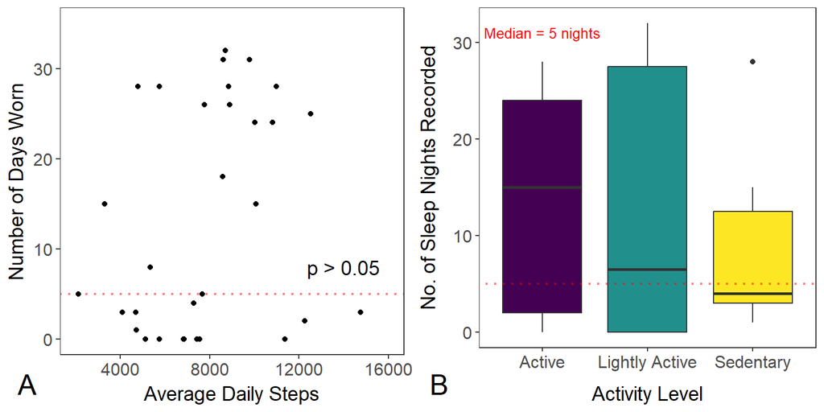

```
## [1] "Spearman Rank Correlation for the number of sleep days vs the average number of daily steps during the study period"
```

```
##
## Call:
## lm(formula = rank(sleep_days_used) ~ rank(avg_steps), data = data)
##
## Residuals:
##      Min       1Q   Median       3Q      Max
## -15.1578 -10.0264   0.7238   7.3158  15.2106
##
## Coefficients:
##                 Estimate Std. Error t value Pr(>|t|)
## (Intercept)      13.6449     3.3891   4.026  0.00034 ***
## rank(avg_steps)   0.1974     0.1739   1.135  0.26520
## ---
## Signif. codes:  0 '***' 0.001 '**' 0.01 '*' 0.05 '.' 0.1 ' ' 1
##
## Residual standard error: 9.514 on 31 degrees of freedom
## Multiple R-squared:  0.03988,    Adjusted R-squared:  0.008905
## F-statistic: 1.288 on 1 and 31 DF,  p-value: 0.2652
```

## **7. Conclusions**

1. At a high level, this analysis shows some general patterns in fitness behavior. For example, highly active users are more active during lunch and after work hours, however; there is no indication among fitness groups that people would be more active over the weekends as was hypothesized.
2. While it was hypothesized that sedentary users would likely sleep more, there was no difference in sleep activity among users of different activity levels.
3. On average, people who take more daily steps are likely to wear their fitness watch more consistently, however, this was not the case for wearing the fitness watches at night time, which had no predictable trends.